# Red Wine Exploration by Jose Ballesteros

```
##   X fixed.acidity volatile.acidity citric.acid residual.sugar chlorides
## 1 1           7.4             0.70        0.00            1.9     0.076
## 2 2           7.8             0.88        0.00            2.6     0.098
## 3 3           7.8             0.76        0.04            2.3     0.092
## 4 4          11.2             0.28        0.56            1.9     0.075
## 5 5           7.4             0.70        0.00            1.9     0.076
## 6 6           7.4             0.66        0.00            1.8     0.075
##   free.sulfur.dioxide total.sulfur.dioxide density   pH sulphates alcohol
## 1                  11                   34  0.9978 3.51      0.56     9.4
## 2                  25                   67  0.9968 3.20      0.68     9.8
## 3                  15                   54  0.9970 3.26      0.65     9.8
## 4                  17                   60  0.9980 3.16      0.58     9.8
## 5                  11                   34  0.9978 3.51      0.56     9.4
## 6                  13                   40  0.9978 3.51      0.56     9.4
##   quality
## 1       5
## 2       5
## 3       5
## 4       6
## 5       5
## 6       5
```

```
##  [1] "X"                    "fixed.acidity"        "volatile.acidity"
##  [4] "citric.acid"          "residual.sugar"       "chlorides"
##  [7] "free.sulfur.dioxide"  "total.sulfur.dioxide" "density"
## [10] "pH"                   "sulphates"            "alcohol"
## [13] "quality"
```

> After loading the dataset, it was discovered that the X variable was only used as an index. As a result, the X variable was removed.

```
##  [1] "fixed.acidity"        "volatile.acidity"     "citric.acid"
##  [4] "residual.sugar"       "chlorides"            "free.sulfur.dioxide"
##  [7] "total.sulfur.dioxide" "density"              "pH"
## [10] "sulphates"            "alcohol"              "quality"
```

```
## [1] 1599   12
```

> The Red Wine dataset explores 11 physicochemical and sensory characteristics on 1,599 samples of Portuguese “Vinho Verde” Red Wine to their relation with overall quality.

# Univariate Plots Section

```
##  fixed.acidity   volatile.acidity  citric.acid    residual.sugar
##  Min.   : 4.60   Min.   :0.1200   Min.   :0.000   Min.   : 0.900
##  1st Qu.: 7.10   1st Qu.:0.3900   1st Qu.:0.090   1st Qu.: 1.900
##  Median : 7.90   Median :0.5200   Median :0.260   Median : 2.200
##  Mean   : 8.32   Mean   :0.5278   Mean   :0.271   Mean   : 2.539
##  3rd Qu.: 9.20   3rd Qu.:0.6400   3rd Qu.:0.420   3rd Qu.: 2.600
##  Max.   :15.90   Max.   :1.5800   Max.   :1.000   Max.   :15.500
##    chlorides       free.sulfur.dioxide total.sulfur.dioxide
##  Min.   :0.01200   Min.   : 1.00       Min.   :  6.00
##  1st Qu.:0.07000   1st Qu.: 7.00       1st Qu.: 22.00
##  Median :0.07900   Median :14.00       Median : 38.00
##  Mean   :0.08747   Mean   :15.87       Mean   : 46.47
##  3rd Qu.:0.09000   3rd Qu.:21.00       3rd Qu.: 62.00
##  Max.   :0.61100   Max.   :72.00       Max.   :289.00
##     density             pH          sulphates         alcohol
##  Min.   :0.9901   Min.   :2.740   Min.   :0.3300   Min.   : 8.40
##  1st Qu.:0.9956   1st Qu.:3.210   1st Qu.:0.5500   1st Qu.: 9.50
##  Median :0.9968   Median :3.310   Median :0.6200   Median :10.20
##  Mean   :0.9967   Mean   :3.311   Mean   :0.6581   Mean   :10.42
##  3rd Qu.:0.9978   3rd Qu.:3.400   3rd Qu.:0.7300   3rd Qu.:11.10
##  Max.   :1.0037   Max.   :4.010   Max.   :2.0000   Max.   :14.90
##     quality
##  Min.   :3.000
##  1st Qu.:5.000
##  Median :6.000
##  Mean   :5.636
##  3rd Qu.:6.000
##  Max.   :8.000
```

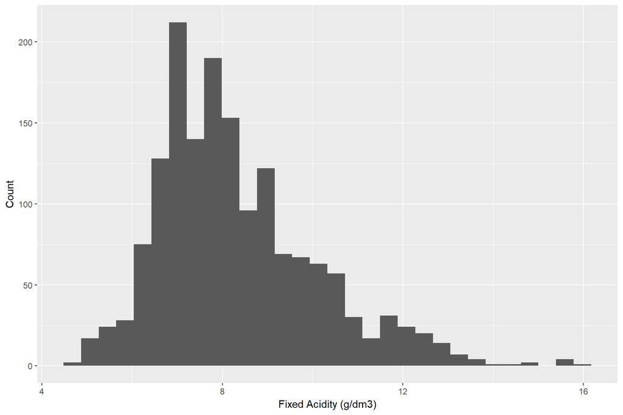

> Fixed acidity measured the amount of tartaric acid in the red wine. Fixed acidity ranged from 4.60 to 15.90 g/dm3. It has a positively screwed distribution with a median of 7.90 g/dm3.

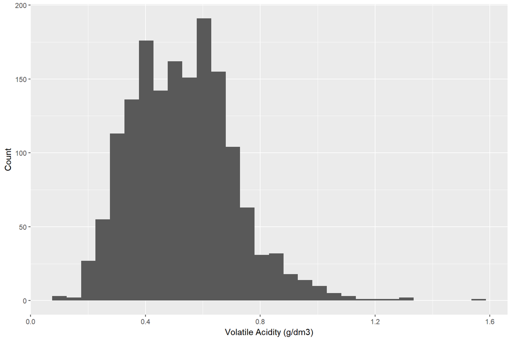

> Volatile Acidity measured the amount of acetic acid in the red wine and ranged from .12 to 1.58 g/dm3. The median was .52 g/dm3. The distrution has a slight positive skewed output.

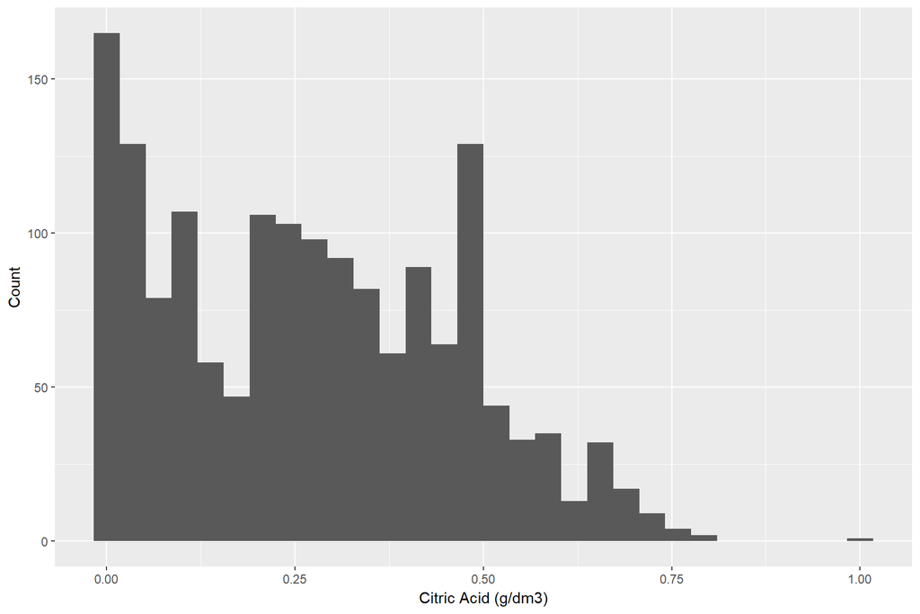

> Citric acid has a positively skewed distribution with a range of 0 to 1.0 g/dm3. The median had a value of .26 g/dm3.

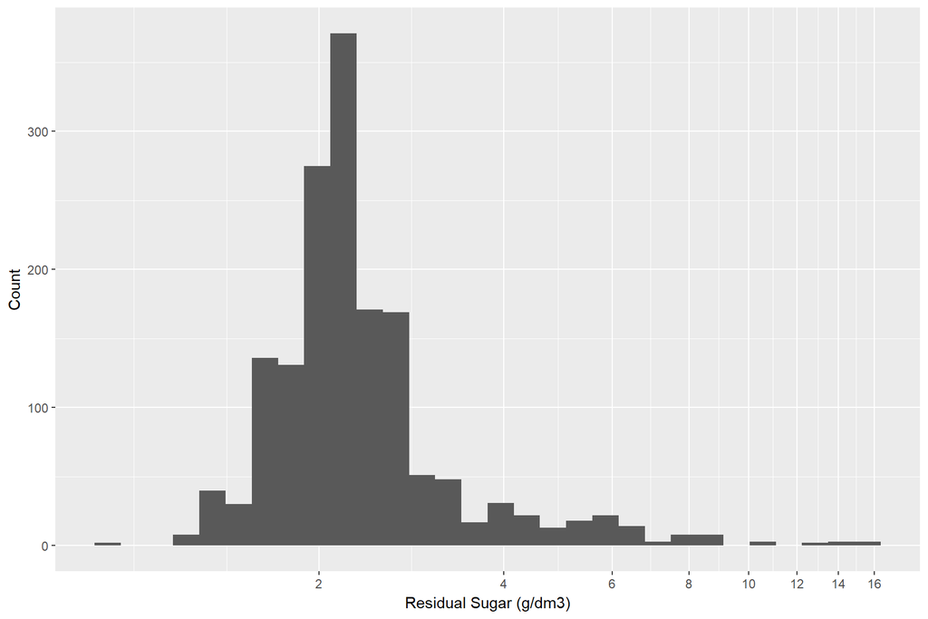

> The residual sugar plot initially had a very high positively skewed distribution. As a result, the log10 was applied to residual sugar.The residual sugar ranged from .90 to 15.50 g/dm3. The median had a value of 2.20 g/dm3.

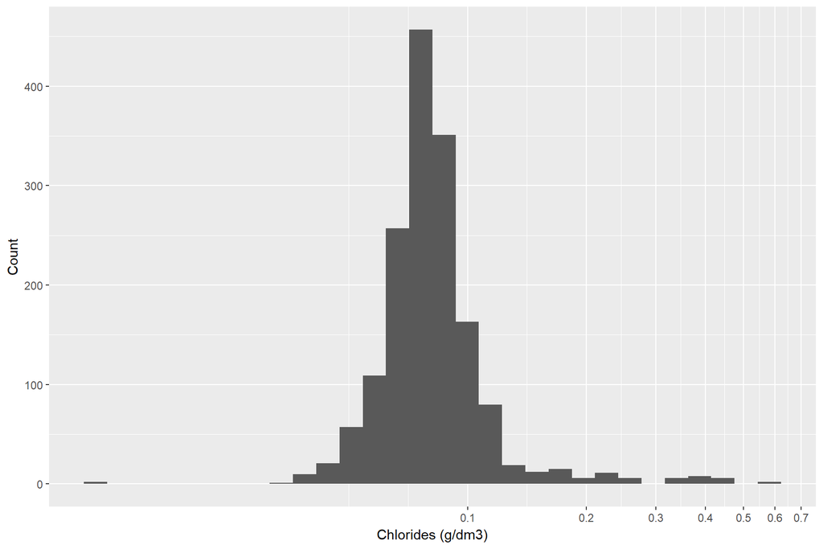

> The amount of sodium chloride was measured to calculate the amount of chlorides in the different samples. The log10 was applied to reduce the positive skewness it had before. The amount of chlorides ranged from .012 to .611 g/dm3 and had a median of .079 g/dm3.

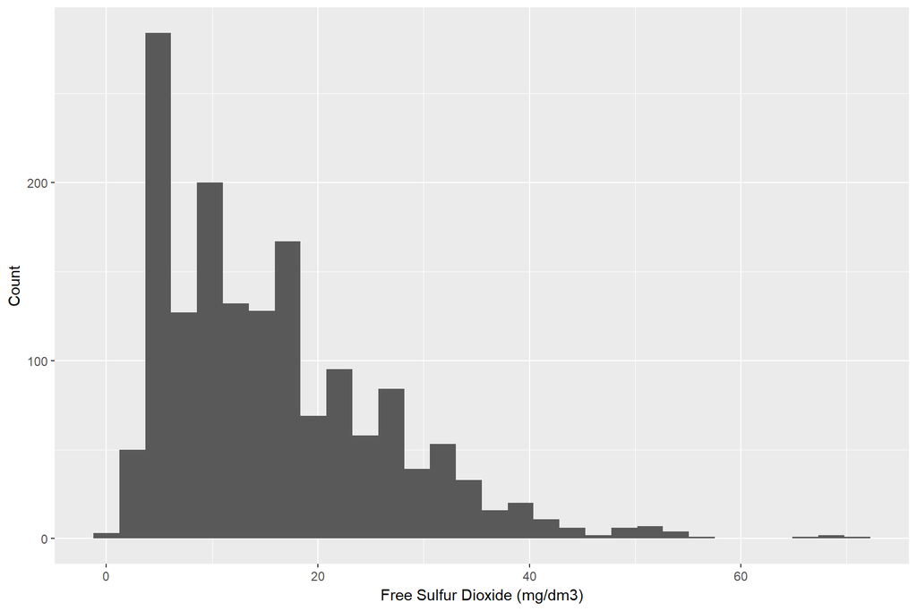

> The free sulfur dioxide plot showed a high level of positive skewness. The range was from 1.0 to 72.0 mg/dm3. The median had a value of 14 mg/dm3.

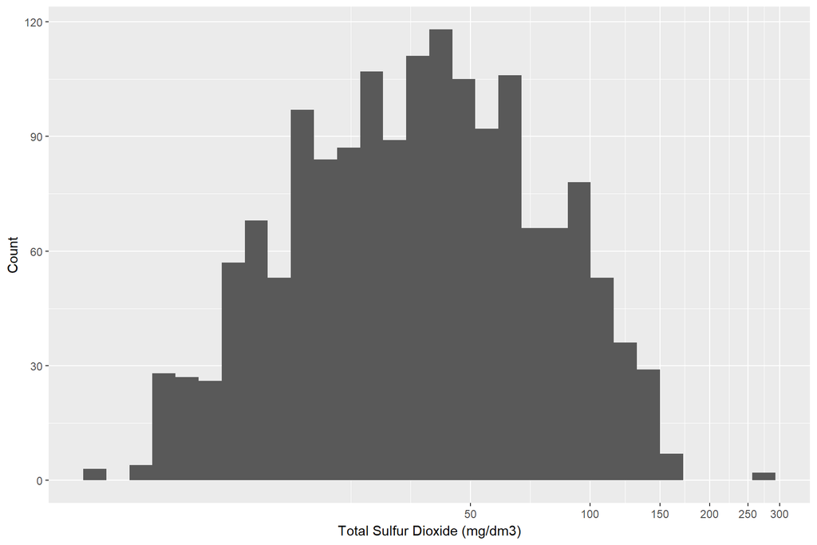

> The log10 was applied to the total sulfur dioxide plot. Without the log10, it displayed a highly positive skewed distribution.The amount of total sulfur dioxide ranged from 6.0 to 289.0 mg/dm3.The median value was of 38.0 mg/dm3.

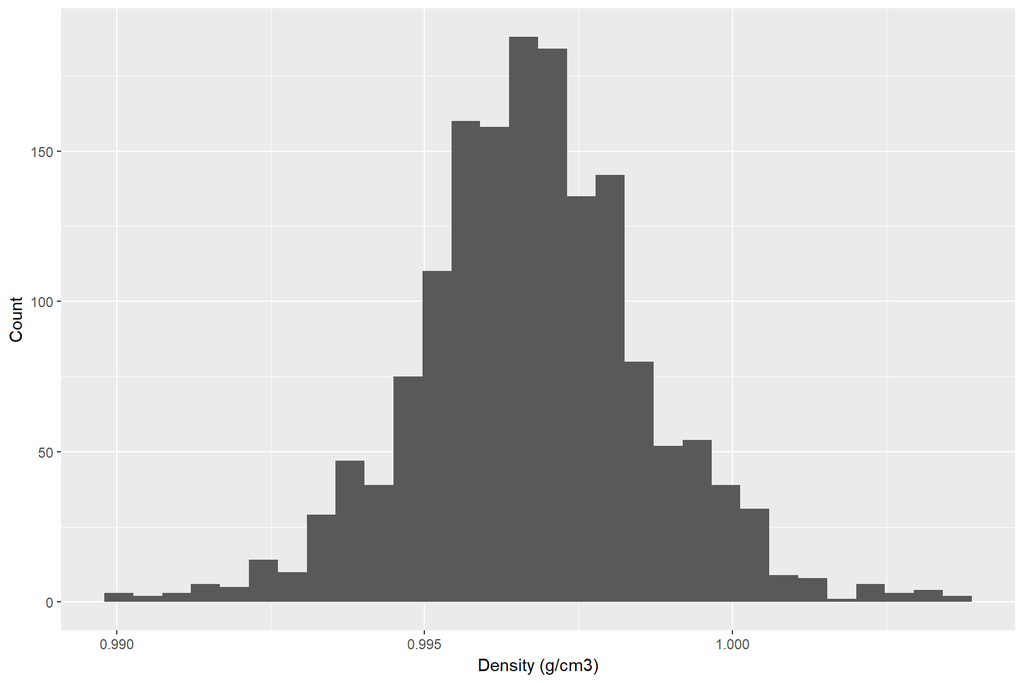

> The density of the samples ranged from.9901 to 1.0037 g/cm3 and had a median value of .9968 g/cm3.This chart shows density to be normally distributed.

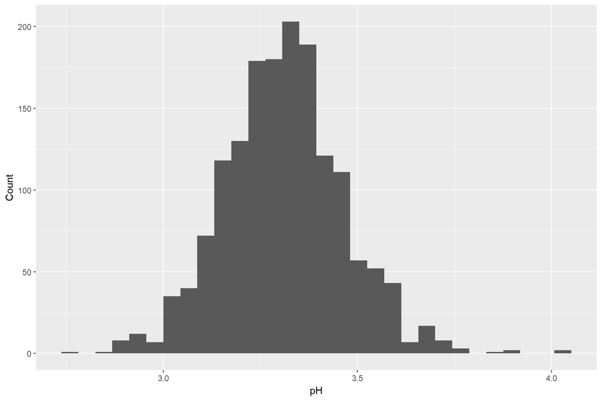

> The pH ranged from 2.74 to 4.01 and had a median value of 3.310. The pH displays normal distribution.

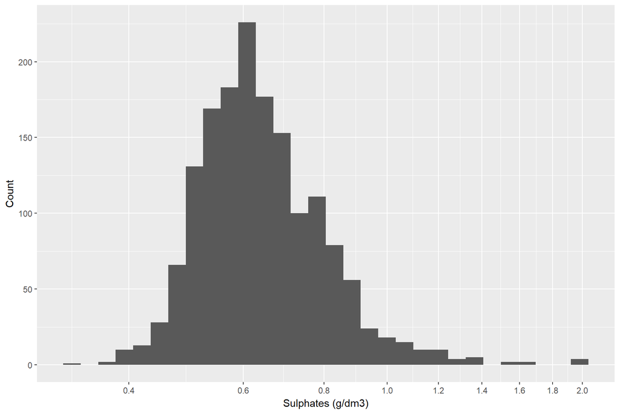

> Potassium sulphate was used to measure the amount of sulphates in the red wine.The log10 was applied to reduce some of the positive skewness it had before. The amount of sulphates ranged from .33 to 2.00 g/dm3 and had median of .62 g/dm3.

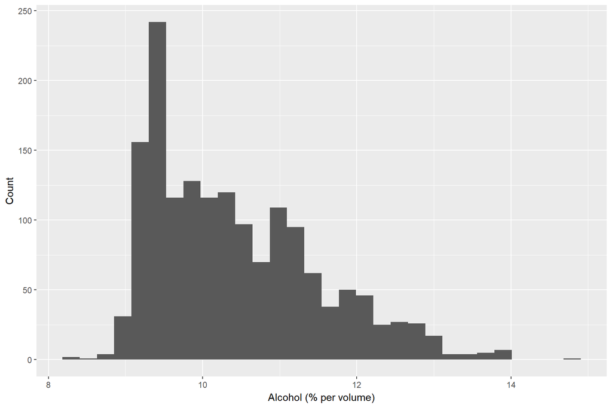

> The alcohol content ranged from 8.40 to 14.90 percent per volume. The median value was of 10.20. It shows a positively skewed distribution.

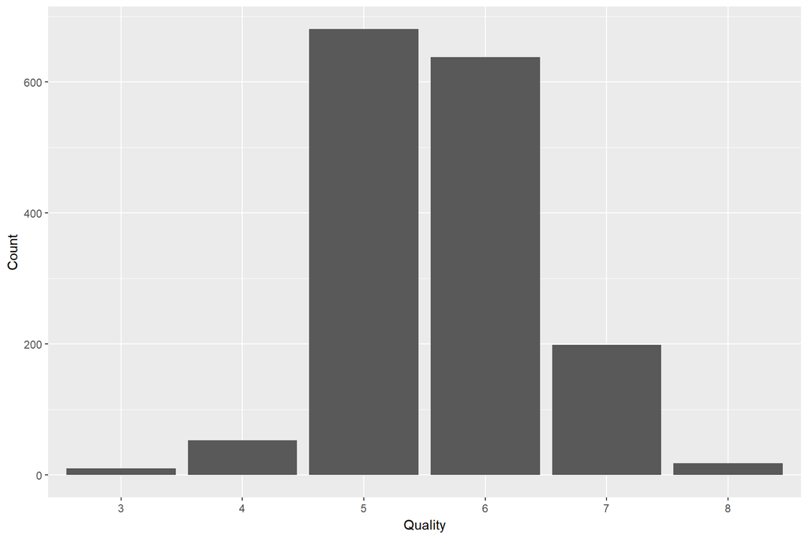

> Quality of the wines was the outcome of the study from this dataset. The score ranged from 3 to 8. The median quality was 6.

# Univariate Analysis

### Dataset Structure

```
## 'data.frame':    1599 obs. of  12 variables:
##  $ fixed.acidity       : num  7.4 7.8 7.8 11.2 7.4 7.4 7.9 7.3 7.8 7.5 ...
##  $ volatile.acidity    : num  0.7 0.88 0.76 0.28 0.7 0.66 0.6 0.65 0.58 0.5 ...
##  $ citric.acid         : num  0 0 0.04 0.56 0 0 0.06 0 0.02 0.36 ...
##  $ residual.sugar      : num  1.9 2.6 2.3 1.9 1.9 1.8 1.6 1.2 2 6.1 ...
##  $ chlorides           : num  0.076 0.098 0.092 0.075 0.076 0.075 0.069 0.065 0.073 0.071 ...
##  $ free.sulfur.dioxide : num  11 25 15 17 11 13 15 15 9 17 ...
##  $ total.sulfur.dioxide: num  34 67 54 60 34 40 59 21 18 102 ...
##  $ density             : num  0.998 0.997 0.997 0.998 0.998 ...
##  $ pH                  : num  3.51 3.2 3.26 3.16 3.51 3.51 3.3 3.39 3.36 3.35 ...
##  $ sulphates           : num  0.56 0.68 0.65 0.58 0.56 0.56 0.46 0.47 0.57 0.8 ...
##  $ alcohol             : num  9.4 9.8 9.8 9.8 9.4 9.4 9.4 10 9.5 10.5 ...
##  $ quality             : int  5 5 5 6 5 5 5 7 7 5 ...
```

> The structure of this dataset consisted of 11 input variables and quality as the output variable. All of the input variables were of numeric data types. The quality output variable was an integer value. The quality variable was used throughout the remaining portion of this analysis as a categorical variable with the help of the as.factor function. No new variables were created besides converting the data type.

> My interest within the dataset was wanting to know more about what physiochemical properties would better describe the results of the different quality scores. As shown in the quality histogram, the majority of the wines in the sample received a score of 5 and 6. Many univariate plots initially had a positively skewed plot. These plots were then modified by incorporating a log10 scale that at times improved the distributions as is the case with chlorides, residual sugars, sulphates and the total sulfur dioxide. The remaining plots that still have a slight positive skewness did not change after applying the log10 modification. As a result, the log10 was not applied as there was no noticeable change. The density and pH plot were the only two that were normally distributed without any further modifications.

# Bivariate Plots Section

```
##                     fixed.acidity volatile.acidity citric.acid
## fixed.acidity                1.00            -0.26        0.67
## volatile.acidity            -0.26             1.00       -0.55
## citric.acid                  0.67            -0.55        1.00
## residual.sugar               0.11             0.00        0.14
## chlorides                    0.09             0.06        0.20
## free.sulfur.dioxide         -0.15            -0.01       -0.06
##                     residual.sugar chlorides free.sulfur.dioxide
## fixed.acidity                 0.11      0.09               -0.15
## volatile.acidity              0.00      0.06               -0.01
## citric.acid                   0.14      0.20               -0.06
## residual.sugar                1.00      0.06                0.19
## chlorides                     0.06      1.00                0.01
## free.sulfur.dioxide           0.19      0.01                1.00
##                     total.sulfur.dioxide density    pH sulphates alcohol
## fixed.acidity                      -0.11    0.67 -0.68      0.18   -0.06
## volatile.acidity                    0.08    0.02  0.23     -0.26   -0.20
## citric.acid                         0.04    0.36 -0.54      0.31    0.11
## residual.sugar                      0.20    0.36 -0.09      0.01    0.04
## chlorides                           0.05    0.20 -0.27      0.37   -0.22
## free.sulfur.dioxide                 0.67   -0.02  0.07      0.05   -0.07
##                     quality
## fixed.acidity          0.12
## volatile.acidity      -0.39
## citric.acid            0.23
## residual.sugar         0.01
## chlorides             -0.13
## free.sulfur.dioxide   -0.05
```

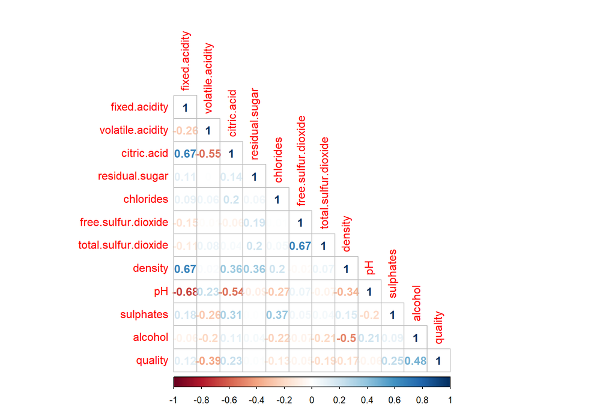

> The corrplot function was used to see which variables had high correlation among them for further analysis.

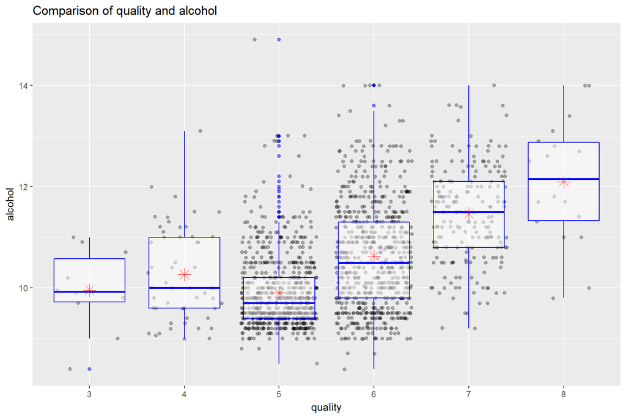

> The correlation between quality and alcohol was a positve relation at .4761.The jitter and alpha function were used to improve the output of the plot.

```
##
##  Pearson's product-moment correlation
##
## data:  redWine1$quality and redWine1$alcohol
## t = 21.639, df = 1597, p-value < 2.2e-16
## alternative hypothesis: true correlation is not equal to 0
## 95 percent confidence interval:
##  0.4373540 0.5132081
## sample estimates:
##       cor
## 0.4761663
```

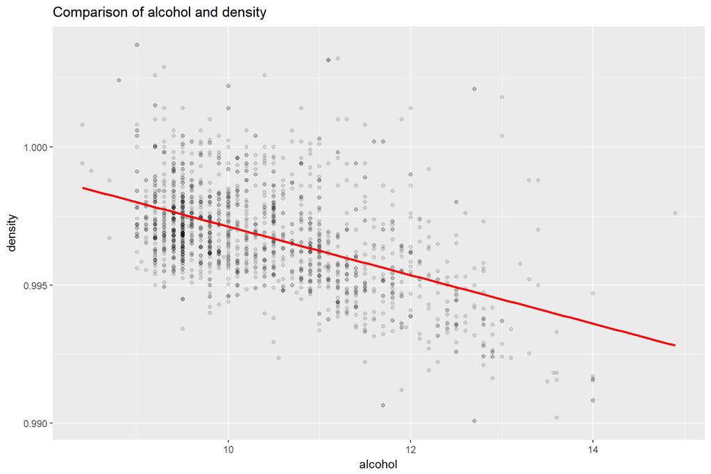

> Alcohol and density had a negative relationship with a correlation of -.496.The alpha function was used to improve the output of the scatter plot.

```
##
##  Pearson's product-moment correlation
##
## data:  redWine1$alcohol and redWine1$density
## t = -22.838, df = 1597, p-value < 2.2e-16
## alternative hypothesis: true correlation is not equal to 0
## 95 percent confidence interval:
##  -0.5322547 -0.4583061
## sample estimates:
##        cor
## -0.4961798
```

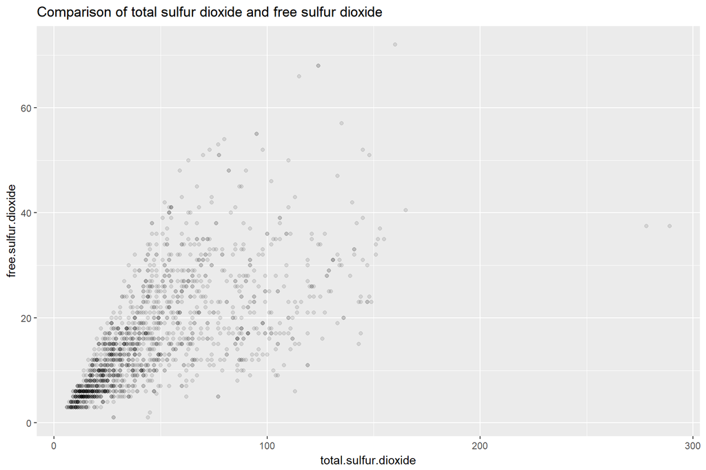

> The total sulfur and free sulfur dioxide had a positive relationship with a correlation of .668.

```
##
##  Pearson's product-moment correlation
##
## data:  redWine1$total.sulfur.dioxide and redWine1$free.sulfur.dioxide
## t = 35.84, df = 1597, p-value < 2.2e-16
## alternative hypothesis: true correlation is not equal to 0
## 95 percent confidence interval:
##  0.6395786 0.6939740
## sample estimates:
##       cor
## 0.6676665
```

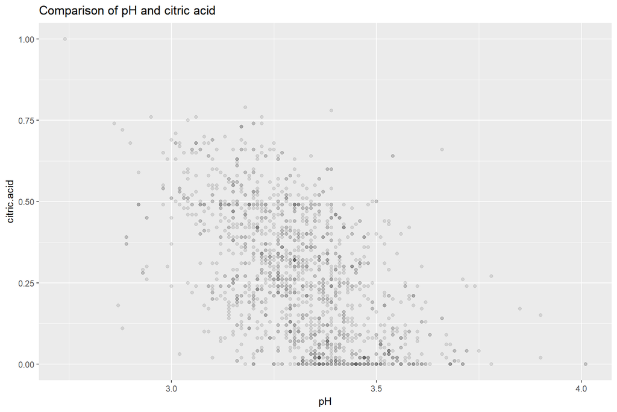

> Citric acid and pH had a negative relation with a correlation of -.542.

```
##
##  Pearson's product-moment correlation
##
## data:  redWine1$pH and redWine1$citric.acid
## t = -25.767, df = 1597, p-value < 2.2e-16
## alternative hypothesis: true correlation is not equal to 0
## 95 percent confidence interval:
##  -0.5756337 -0.5063336
## sample estimates:
##        cor
## -0.5419041
```

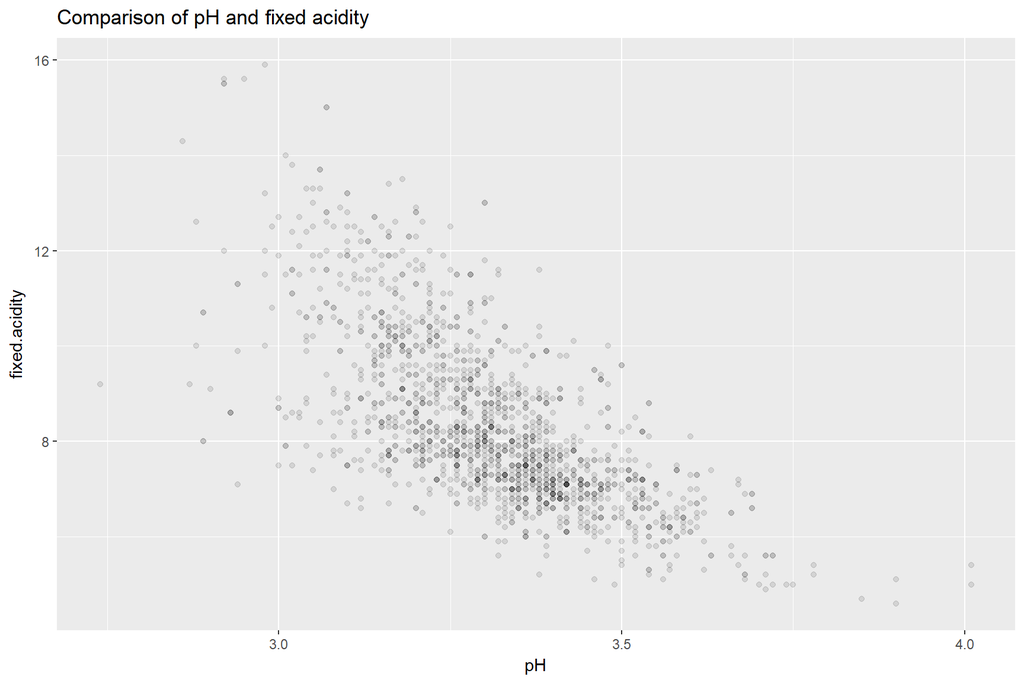

> Fixed acidity and pH had a negative relation with a correlation of -.683.

```
##
##  Pearson's product-moment correlation
##
## data:  redWine1$pH and redWine1$fixed.acidity
## t = -37.366, df = 1597, p-value < 2.2e-16
## alternative hypothesis: true correlation is not equal to 0
## 95 percent confidence interval:
##  -0.7082857 -0.6559174
## sample estimates:
##        cor
## -0.6829782
```

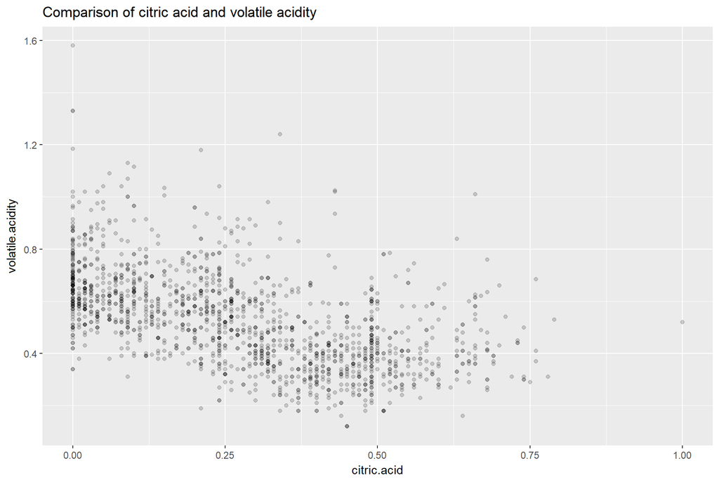

> Citric acid and volatile acidity had a negative relation with a correlation of -.552.

```
##
##  Pearson's product-moment correlation
##
## data:  redWine1$citric.acid and redWine1$volatile.acidity
## t = -26.489, df = 1597, p-value < 2.2e-16
## alternative hypothesis: true correlation is not equal to 0
## 95 percent confidence interval:
##  -0.5856550 -0.5174902
## sample estimates:
##        cor
## -0.5524957
```

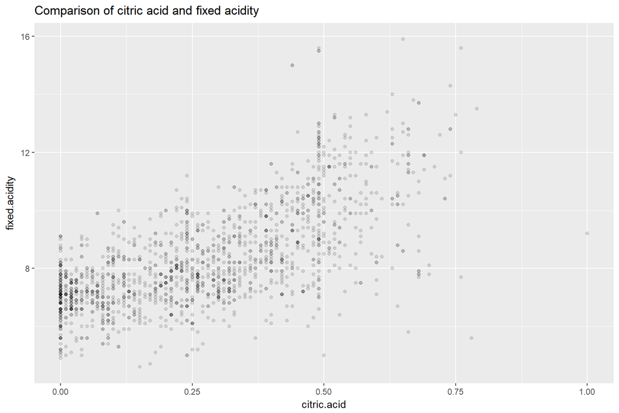

> Citric acid and fixed acidity displays a positive relation with a correlation of .672.

```
##
##  Pearson's product-moment correlation
##
## data:  redWine1$citric.acid and redWine1$fixed.acidity
## t = 36.234, df = 1597, p-value < 2.2e-16
## alternative hypothesis: true correlation is not equal to 0
## 95 percent confidence interval:
##  0.6438839 0.6977493
## sample estimates:
##       cor
## 0.6717034
```

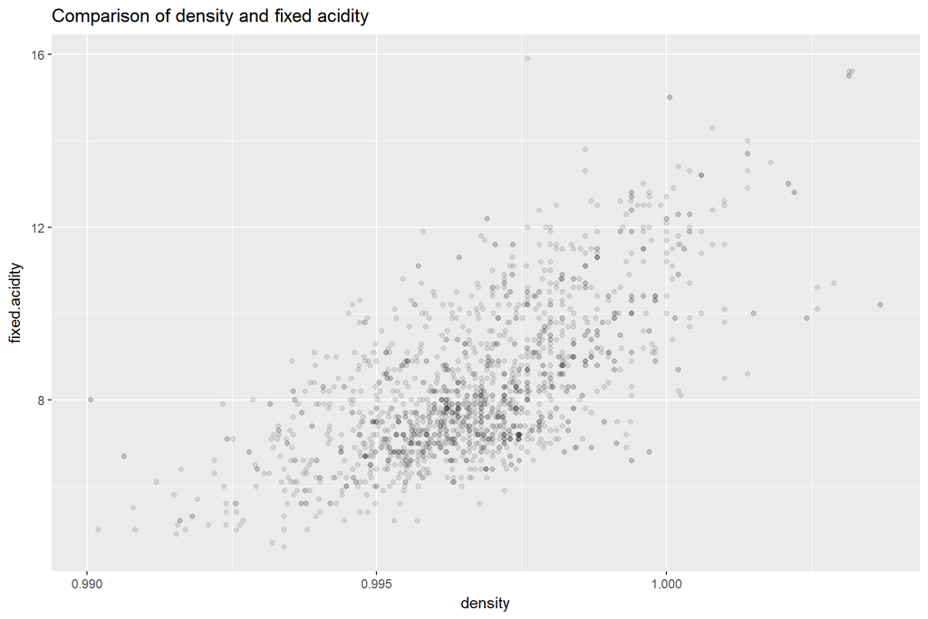

> Density and fixed acidity displays a positive relation with a correlation of .668.

```
##
##  Pearson's product-moment correlation
##
## data:  redWine1$density and redWine1$fixed.acidity
## t = 35.877, df = 1597, p-value < 2.2e-16
## alternative hypothesis: true correlation is not equal to 0
## 95 percent confidence interval:
##  0.6399847 0.6943302
## sample estimates:
##       cor
## 0.6680473
```

# Bivariate Analysis

> After seeing the corrplot, the strongest input variable that had a moderate positive correlation with quality was alcohol. The remaining variables had very low positive correlations with quality. Volatile acidity had the highest negative correlation with quality at -.39.There were also several variables that had strong positve correlations among each other. Fixed acidity had a positive correlation with both citric acid and density at .67. Another positive correlation of .67 was also seen with total and free sulfur dioxide. A slightly lower positive correlation was also seen with alcohol and quality at .48.The highest negative correlation was between fixed acidity and pH levels at -.68. This was followed by citric acid and volatile acidity with a negative .55 value. This relationship was interesting as they both relate to the flavor that will characterize the red wine to have. Citric acid also shared a negative correlation with pH at -.54. Finally, the last variable analyzed was density and alcohol at a negative correlation of .5.

# Multivariate Plots Section

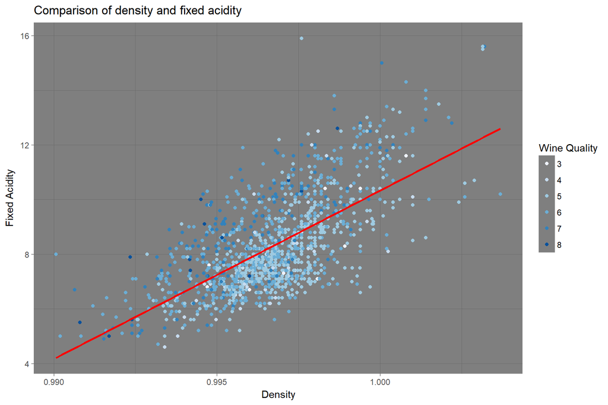

> The bulk of the wines had a quality score of 5 and 6 with a median value of 7.8 and .997 for the fixed acidity and density. Higher quality wines of 7 and above had a median value of 8.7 and .996 for the fixed acidity and density. The lower quality wines of 4 and 3 had a median of 7.5 for the fixed acidity and a density of .997.

| fixedAcidMedian | densityMedian | n |
| --- | --- | --- |
| 7.8 | 0.9968 | 1319 |

| fixedAcidMedian | densityMedian | n |
| --- | --- | --- |
| 8.7 | 0.99572 | 217 |

| fixedAcidMedian | densityMedian | n |
| --- | --- | --- |
| 7.5 | 0.9966 | 63 |

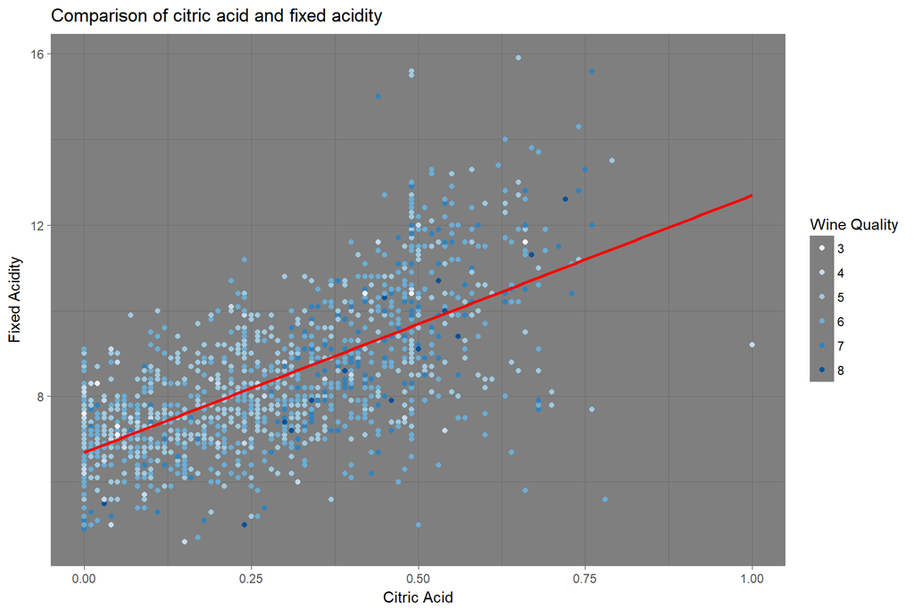

> The majority of the redwines of quality 5 and 6 are centered around .24 for the citric acid and 7.8 for fixed acidity. The higher quality wines are around .4 for the citric acid content and 8.7 for fixed acidity. The lower quality wines are centered around .08 for citric acid and 7.5 for fixed acidity.

| fixedAcidMedian | citricAcidMedian | n |
| --- | --- | --- |
| 7.8 | 0.24 | 1319 |

| fixedAcidMedian | citricAcidMedian | n |
| --- | --- | --- |
| 8.7 | 0.4 | 217 |

| fixedAcidMedian | citricAcidMedian | n |
| --- | --- | --- |
| 7.5 | 0.08 | 63 |

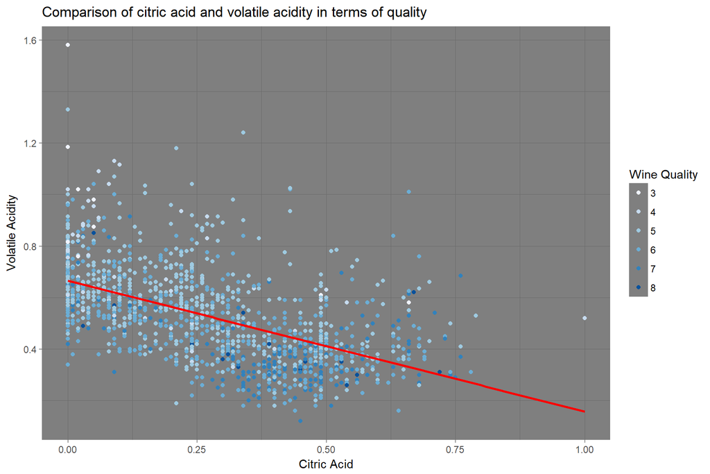

> The plot shows the majority of the wines with a quality of 5 centered above the line of best fit while wines of quality of 6,7, and 8 predominately are found below the line of best fit. As citric acid is increased and volatile acidity is reduced the quality tends to improve.

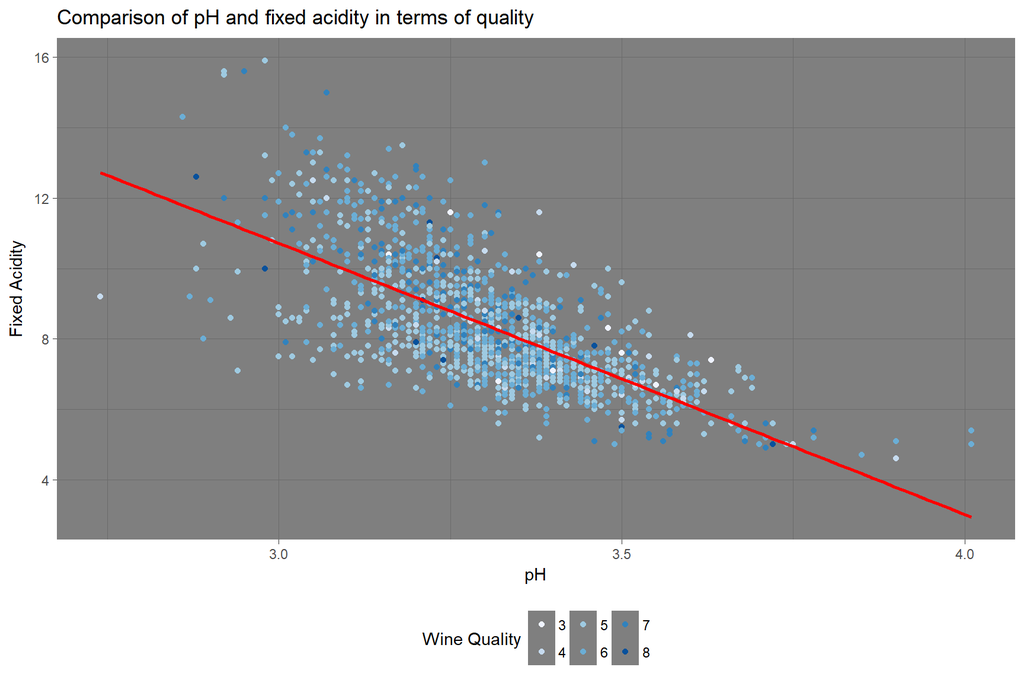

> The quality of the wines can be seen above and below the line of best fit in terms of fixed acidity and pH. The majority of the different qualities tend to be within 3.1 and 3.5 for the pH level and 6 and 10 g/dm3 for the fixed acidity.

# Multivariate Analysis

> The multvariate plots with quality had some plots that were easily seen where the different scoring wines were within the plot. In terms of pH, fixed acidity, and quality, the majority of wines that scored 5 and 6 can be seen distributed above and below the line of best fit. The citric acid, volatile acidity, and quality plot can be seen clearly where different quality of wines are congregating around a specific position below or above. In that plot, 6,7, and 8 scoring wines are seen below the line of best fit and 5 tends to be above the line.

# Final Plots and Summary

### Plot One

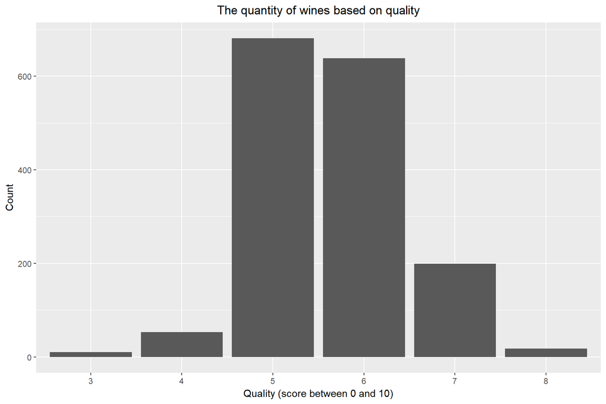

### Description One

> This plot was interesting to see that the majority of the wines got a score of five and six. I was highly surprised to not see many wines that could not manage to get over 7 as a score.

### Plot Two

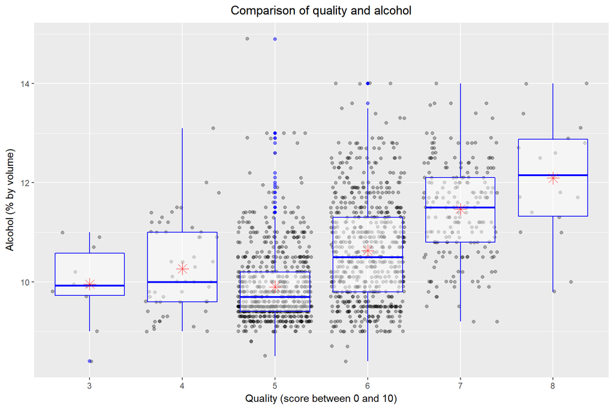

### Description Two

> The relation between quality and alcohol was surprising to see a moderate positve correlation.

### Plot Three

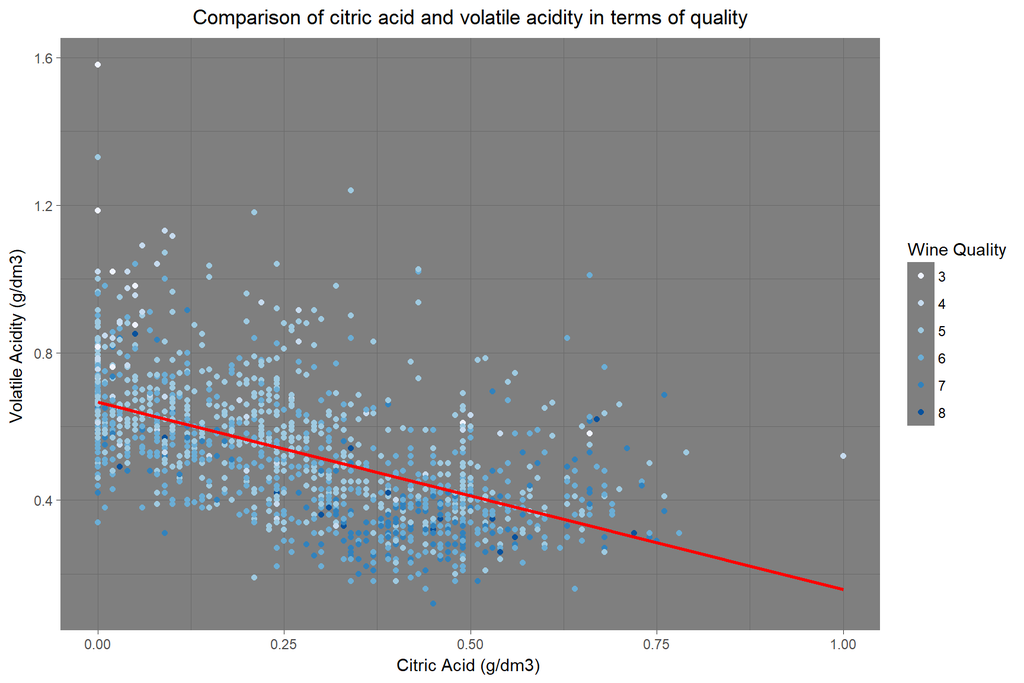

### Description Three

> Volatile acidity and citric acid plays a role with how great the wine tastes.It is visible that the higher volatile acidity levels tend to get scores of 5 and as you decrease the volatile acidity and increase the citric acid to about .30, you get to observe the majority of the 6 and 7’s. This corresponds to the given documentation about volatile acidity and citric acid within this dataset.

# Reflection

> While producing the univariate plots, many of the outputs had noticeable positve skewness. When this occured, I would try to use the scale_x_log10 function to try to reduce the skewness. This did not work with alcohol, fixed acidity, volatile acidity, citric acid, nor free sulfur dioxide. For volatile acidity, citric acid, and free sulfur dioxide it actually created a negative tail distribution. The improvement that the log10 modification had on total sulfur dioxide, chlorides, residual sugars, and sulphates was highly noticeable.The bivariate plot for alcohol and quality initially had a problem with overplotting and did not show great insight. This was improved by using geom_jitter to create some random variation and an alpha value to help improve the visibility of the scatterplot.The remaining bivariate plots also incorporated the alpha function to help produce better visibility of the individual data points.It was interesting to see the multivariate scatterplot between citric acid,volatile acidity, and quality. It was easily shown how the amount of volatile acidity and citric acid plays a large role on the flavoring of the red wine and its final score. Decreasing the volatile acidity and increasing the citric acid to about .30, gets the majority of the wines that scored 6 and 7’s.A future project with this dataset would be to come up with a predictive model that could calculate the quality of the wine by inputing the phsyiochemical values for a wine from the same geographical region.